# Final Info Sheet to Excel

Cameron Smith

12/12/2018

# Last Exam Q&A

```r
#1A: Probability that t with 5 degrees of freedom is greater than or equal to -0.5
ans1A <- 1 - pt(-0.5,5)
#OR
ans1A1 <- pt(-0.5, 5, lower = FALSE)

#1B: Probability that z <= 2
ans1B <- pnorm(2)

#1C: Chisq with 3 degrees of freedom >= 4
ans1C <- 1 - pchisq(4, 3)
#OR
ans1C1 <- pchisq(4, 3, lower = FALSE)

#1D: Probability that a t distribution with 25 degrees of freedom less than or equal to a is equal to .98, where a equals....
ans1D <- qt(.98, 25)

#1E: Probability that a is lessthan or equal to z which is less than or equal to 1 is equal to .5, where a is....
ans1E <- qnorm(pnorm(1) - .5)
ans1E1 <- pnorm(1) - pnorm(qnorm(pnorm(1) - 0.5))
```

1A: $P(t_5 \geq -0.5)$ == 0.6808506 = 0.6808506

1B: $P(z \leq 2)$ == 0.9772499

1C: $P(x^2_3 \geq 4)$ == 0.2614641 = 0.2614641

1D: $P(t_25 \leq a) = .98$ find $a$ == 2.1665866

1E: $P(a \leq z \leq 1) = 0.5$ find $a$ == -0.4087958 = 0.5

Question 3: Suppose you flip 100 biased coins, each with a probability of 0.70 of coming up heads.

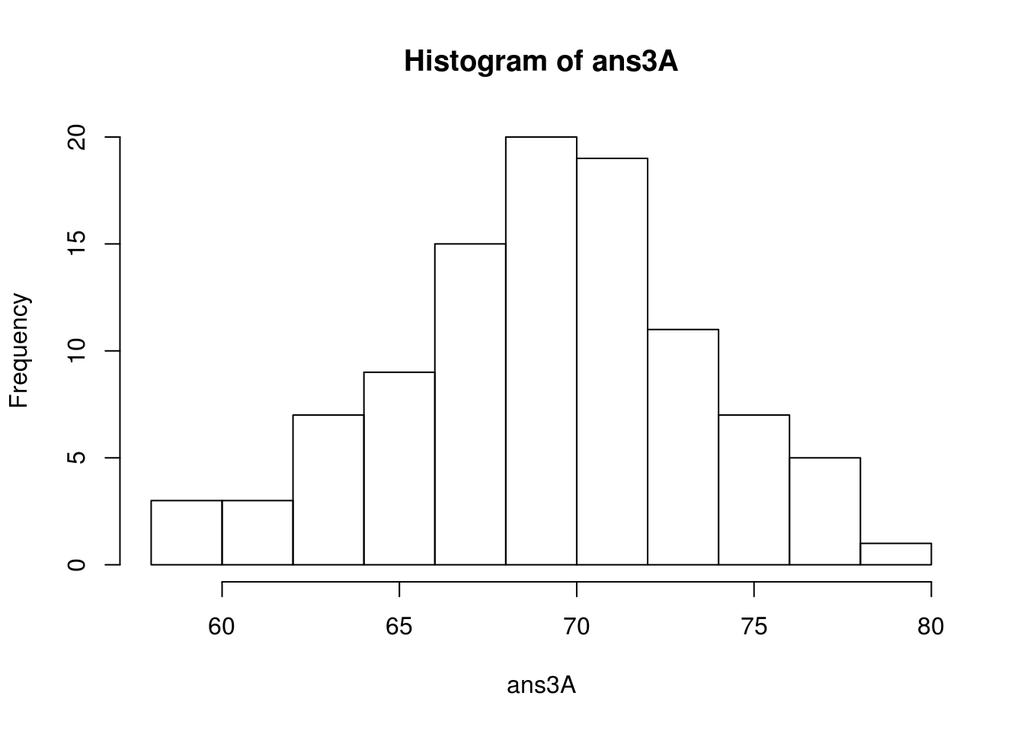

```r
ans3A <- rbinom(n = 100, size = 100, p = 0.7)
hist(ans3A)
```

3A: Define the random variable (X) and specify its distribution

> > X is the number of heads from flipping the coin 100 times of a bias coin. X ~ Bin(n = 100, p = 0.70) == 63, 71, 60, 67, 69, 71, 69, 72, 70, 70, 77, 74, 66, 66, 64, 73, 71, 72, 71, 72, 69, 75, 74, 67, 63, 70, 70, 70, 59, 71, 74, 67, 66, 69, 68, 62, 68, 67, 70, 72, 77, 74, 68, 65, 72, 65, 68, 71, 64, 69, 69, 76, 72, 71, 73, 76, 75, 69, 68, 69, 73, 68, 79, 75, 68, 76, 71, 62, 64, 66, 69, 77, 71, 71, 72, 73, 76, 70, 62, 69, 64, 72, 72, 68, 60, 69, 66, 64, 69, 68, 65, 67, 78, 74, 68, 69, 74, 77, 73, 66

3B: Find the E(X) and V(X) exactly, and verify the reasonableness of your answer with a simulation using 10,000 flips.

```r
# number of coins times the probability of getting heads
EX <- 100 * 0.7
# number of coins times the probability of getting heads times 1 minus the probability of getting heads (or the probability of getting tails)
VX <- 100 * 0.7 * (1-0.7)

#simulation of 10000 flips
draws <- rbinom(10000, 100, 0.7)
#approximately 70
mean(draws)
```

```
## [1] 70.0109
```

```r
#approximately 21
var(draws)
```

```
## [1] 21.32231
```

E(X) = 70 V(X) = 21

3C: What is the probability 80 or more of the coins are heads? Provide an exact answer, and use a simulation of 10000 trials to verify the reasonableness of your exact answer.

```r
#exact answer
ans3C <- sum(dbinom(80:100, 100, 0.7))
#OR
ans3C1 <- 1 - pbinom(80 - 1, 100, .7)

#simulation
ans3Csim <- mean(rbinom(10000, 100, .7) >= 80)
```

exact: 0.0164629 == 0.0164629

simulation: 0.0175

3D: Suppose you obeserve 80 heads after flipping the biased coin 100 times. Use the central limit theorem to approximate the $P(X \geq 80)$ $X \sim N(70, \sqrt{21})$

```r
ans3D <- pnorm(80, 70, sqrt(21), lower = FALSE)
#OR
ans3D1 <- 1 - pnorm(80, 70, sqrt(21))
```

0.0145482 == 0.0145482

4: If $X \sim Bin(n = 20, p = 0.5), Y \sim Bin(n = 30, p = 0.2)$ and X and Y are independent, what is the E(4X - 2Y) and V(4X - 2Y)? Provide an exact answer and use simulation with 10,000 trials to verify the reasonableness of your exact answer.

$E(4X - 2Y) = E(4X) - E(2Y) = 4(20* .5) - 2(30 * .2) = 4 * 10 - 2 * 6 = $

28